# Колку тежи македонскиот парламент? Дел 2: Возен парк

DiscindoDataBrew

## За

Овој документ прикажува податоци за имот на пратеници во Република Македонија објавени од страна на Државната комисија за спречување на корупцијата по конституирање на новиот парламентарен состав во декември 2016.

Податоците се за 100 пратеници бидејќи на веб-сајтот на комисијата до 24.02.2017 само толку анкетни листови се објавени/ажурирани.

Ако најдете грешки, пријавете [тука](https://github.com/novica/databrew/issues). Изворниот код може да се преземе [тука](https://github.com/novica/databrew/).

## Вовед

Во Собранието на Република Македонија има 120 пратеници. Вкупниот сооднос е 38 жени и 82 мажи. Подолу се податоци за 100 од нив: 28 жени и 72 мажи.

Вкупниот имот на овие 100 македонските пратеници е 24 милиони 725 илјади евра пресметан како збир од сите видови имоти минус долговите. [Колку се 24 милиони евра](https://www.google.com/#q=24+%D0%BC%D0%B8%D0%BB%D0%B8%D0%BE%D0%BD%D0%B8+%D0%B5%D0%B2%D1%80%D0%B0)?

### Возниот парк на пратениците

Македонските пратеници и нивните семејства поседуваат вкупно 161 моторни возила со вкупна вредност од 1.756.270,00 евра. Просечната старост на пратеничките возила е 13,45 години. Тоа е помалку од републичкиот просек каде трендот се движи помеѓу [14,43 и 17,7 години](http://www.moepp.gov.mk/?page_id=5794).

Најпопуларно возило помеѓу пратениците е Фолксваген (28), а потоа следат Мерцедес (19) и Ауди (11). Помеѓу возилата има и еден Јагуар и две Југа. Најмногу моторни возила има пратеникот Борис Змејковски (8), а дури 10 пратеници и нивните семејства (вклучувајќи ги Зоран Заев и Никола Груевски) немаат ниту едно возило.

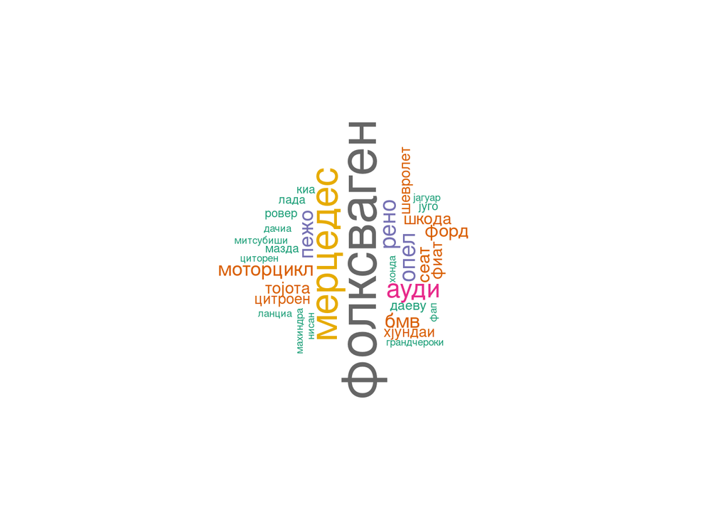

Слика 1: Возилата на пратениците